# Data Wrangling Project 2

Vamsi K Mamidi

September 26, 2017

### Loading Packages

```r
library (tidyr)
library (readr)
library (dplyr)
```

## Load the data in RStudio

```r
titanic_original <- read_csv("titanic_original.csv",col_names = TRUE)
```

### Output

```r
glimpse(titanic_original)
```

```
## Observations: 1,310
## Variables: 14
## $ pclass    <int> 1, 1, 1, 1, 1, 1, 1, 1, 1, 1, 1, 1, 1, 1, 1, 1, 1, 1...
## $ survived  <int> 1, 1, 0, 0, 0, 1, 1, 0, 1, 0, 0, 1, 1, 1, 1, 0, 0, 1...
## $ name      <chr> "Allen, Miss. Elisabeth Walton", "Allison, Master. H...
## $ sex       <chr> "female", "male", "female", "male", "female", "male"...
## $ age       <dbl> 29.0000, 0.9167, 2.0000, 30.0000, 25.0000, 48.0000, ...
## $ sibsp     <int> 0, 1, 1, 1, 1, 0, 1, 0, 2, 0, 1, 1, 0, 0, 0, 0, 0, 0...
## $ parch     <int> 0, 2, 2, 2, 2, 0, 0, 0, 0, 0, 0, 0, 0, 0, 0, 0, 1, 1...
## $ ticket    <chr> "24160", "113781", "113781", "113781", "113781", "19...
## $ fare      <dbl> 211.3375, 151.5500, 151.5500, 151.5500, 151.5500, 26...
## $ cabin     <chr> "B5", "C22 C26", "C22 C26", "C22 C26", "C22 C26", "E...
## $ embarked  <chr> "S", "S", "S", "S", "S", "S", "S", "S", "S", "C", "C...
## $ boat      <chr> "2", "11", NA, NA, NA, "3", "10", NA, "D", NA, NA, "...
## $ body      <int> NA, NA, NA, 135, NA, NA, NA, NA, NA, 22, 124, NA, NA...
## $ home.dest <chr> "St Louis, MO", "Montreal, PQ / Chesterville, ON", "...
```

## Port of embarkation

```r
titanic_original %>%filter(is.na(embarked))
```

```
## # A tibble: 3 x 14
##   pclass survived                                      name    sex   age
##    <int>    <int>                                     <chr>  <chr> <dbl>
## 1      1        1                       Icard, Miss. Amelie female    38
## 2      1        1 Stone, Mrs. George Nelson (Martha Evelyn) female    62
## 3     NA       NA                                      <NA>   <NA>    NA
## # ... with 9 more variables: sibsp <int>, parch <int>, ticket <chr>,
## #   fare <dbl>, cabin <chr>, embarked <chr>, boat <chr>, body <int>,
## #   home.dest <chr>
```

```r
titanic_original <- titanic_original %>% replace_na(list(embarked = "S"), embarked)
```

### Output:

```r
titanic_original %>%select(embarked)%>%unique()
```

```
## # A tibble: 3 x 1
##   embarked
##      <chr>
## 1        S
## 2        C
## 3        Q
```

## AGE

Calculated Mean, Meadian, Min, Max after removing the missing values

```r
titanic_original%>%filter(!is.na(age))%>%summarise(mean=mean(age),max=max(age),min=min(age),median=median(age))
```

```
## # A tibble: 1 x 4
##       mean   max    min median
##      <dbl> <dbl>  <dbl>  <dbl>
## 1 29.88113    80 0.1667     28
```

The below plot is a scattered plot of ages vs Frequency, after removing the missing ages. we can see that the propability of a missing age value around the mean is more compared with other age groups.

### AGE DISTRIBUTION

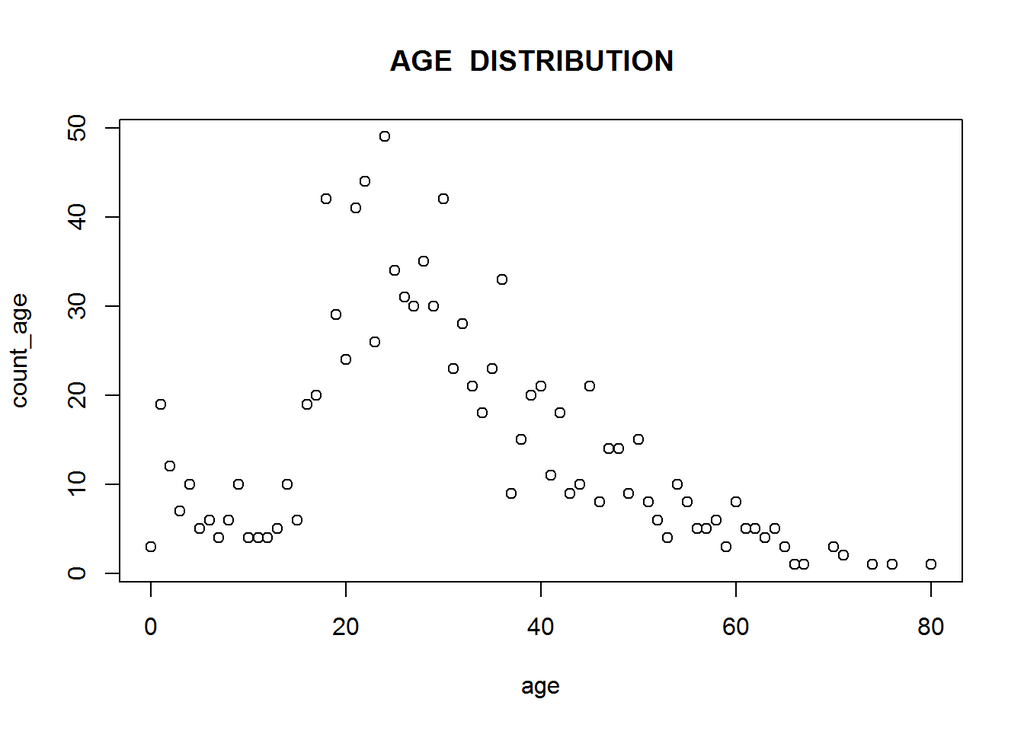

```r
titanic_original%>%filter(!is.na(age))%>%mutate(age=round(age,0))%>%group_by(age)%>%summarise(count_age=n())%>%arrange(desc(count_age))%>%with(plot(age,count_age,main = "AGE  DISTRIBUTION  "))
```

### AGE DISTRIBUTION by Gender

There are other ways to determine the missing age values which require more detail analysis by including other features like gender. For example we can calculate the mean age for both male and Female and we can replace the male missing age value with male mean age and female missing age with female mean age

```r
titanic_original%>%filter(!is.na(age))%>%group_by(sex)%>%summarise(mean=mean(age),max=max(age),min=min(age),median=median(age))
```

```
## # A tibble: 2 x 5
##      sex     mean   max    min median
##    <chr>    <dbl> <dbl>  <dbl>  <dbl>
## 1 female 28.68707    76 0.1667     27
## 2   male 30.58523    80 0.3333     28
```

[figure not shown]

```r
titanic_original%>%filter(!is.na(age))%>%mutate(age=round(age,0))%>%group_by(age,sex)%>%summarise(count_age=n())%>%arrange(desc(count_age))%>%with(plot(age,count_age,col=c("red","blue"),main = "AGE  DISTRIBUTION BY GENDER "))
legend(x=64,y=30,legend=c("FEMALE","MALE"),fill=c("red","blue"))
```

I assume that by replacing the missing values depending on gender mean ages is better than just replacing all the missing age values with overall age mean, because as we can see that the distribution of age for male and female are different.

### Replacing missing age values with gender age mean

```r
titanic_original<-titanic_original%>%mutate(age=ifelse(is.na(age) & sex=="male" , 30.58523, ifelse(is.na(age) & sex=="female" , 28.68707,age)))
```

## Lifeboat

Fill these empty slots with a dummy value e.g. the string ‘None’ or ‘NA’

```r
titanic_original<-titanic_original%>%mutate(boat=ifelse(is.na(boat)  ,"None",boat))
```

### Output:

```r
titanic_original%>%group_by(boat)%>%summarise(count_boat=n())%>%arrange(desc(count_boat))
```

```
## # A tibble: 28 x 2
##     boat count_boat
##    <chr>      <int>
##  1  None        824
##  2    13         39
##  3     C         38
##  4    15         37
##  5    14         33
##  6     4         31
##  7    10         29
##  8     5         27
##  9     3         26
## 10    11         25
## # ... with 18 more rows
```

## Cabin

Create a new column has_cabin_number which has 1 if there is a cabin number, and 0 otherwise.

```r
titanic_original<-titanic_original%>%mutate(has_cabin_number=ifelse(is.na(cabin)  ,0,1))
```

### Output:

```r
titanic_original%>%select(cabin,has_cabin_number,survived)
```

```
## # A tibble: 1,310 x 3
##      cabin has_cabin_number survived
##      <chr>            <dbl>    <int>
##  1      B5                1        1
##  2 C22 C26                1        1
##  3 C22 C26                1        0
##  4 C22 C26                1        0
##  5 C22 C26                1        0
##  6     E12                1        1
##  7      D7                1        1
##  8     A36                1        0
##  9    C101                1        1
## 10    <NA>                0        0
## # ... with 1,300 more rows
```

### Table for Survied Vs has Cabin number

```r
titanic_original%>%filter(! is.na(survived))%>%group_by(survived,has_cabin_number)%>%summarise(count_survied=n())
```

```
## # A tibble: 4 x 3
## # Groups:   survived [?]
##   survived has_cabin_number count_survied
##      <int>            <dbl>         <int>
## 1        0                0           707
## 2        0                1           102
## 3        1                0           307
## 4        1                1           193
```

# Create a CSV file

```r
write.csv(titanic_original, "titanic_clean.csv")
```